# Risk Factor Analysis

## Outcome Variable

**Outcome Variable:** ever_stunted

## Predictor Variables

**Intervention Variable:** parity

**Adjustment Set:**

- arm
- W_mage
- meducyrs
- feducyrs
- hhwealth_quart
- W_mhtcm
- vagbrth
- W_nrooms
- impfloor
- impsan
- safeh20
- delta_W_mage
- delta_meducyrs
- delta_feducyrs
- delta_hhwealth_quart
- delta_W_mhtcm
- delta_vagbrth
- delta_W_nrooms
- delta_impfloor
- delta_impsan
- delta_safeh20

## Stratifying Variables

The analysis was stratified on these variable(s):

- agecat
- studyid
- country

## Data Summary

| agecat | studyid | country | parity | ever_stunted | n_cell | n |
| --- | --- | --- | --- | --- | --- | --- |
| 0-24 months | ki1000304b-SAS-CompFeed | INDIA | 1 | 0 | 162 | 1533 |
| 0-24 months | ki1000304b-SAS-CompFeed | INDIA | 1 | 1 | 290 | 1533 |
| 0-24 months | ki1000304b-SAS-CompFeed | INDIA | 2 | 0 | 122 | 1533 |
| 0-24 months | ki1000304b-SAS-CompFeed | INDIA | 2 | 1 | 238 | 1533 |
| 0-24 months | ki1000304b-SAS-CompFeed | INDIA | 3+ | 0 | 189 | 1533 |
| 0-24 months | ki1000304b-SAS-CompFeed | INDIA | 3+ | 1 | 532 | 1533 |
| 0-24 months | ki1000304b-SAS-FoodSuppl | INDIA | 1 | 0 | 19 | 397 |
| 0-24 months | ki1000304b-SAS-FoodSuppl | INDIA | 1 | 1 | 58 | 397 |
| 0-24 months | ki1000304b-SAS-FoodSuppl | INDIA | 2 | 0 | 12 | 397 |
| 0-24 months | ki1000304b-SAS-FoodSuppl | INDIA | 2 | 1 | 80 | 397 |
| 0-24 months | ki1000304b-SAS-FoodSuppl | INDIA | 3+ | 0 | 28 | 397 |
| 0-24 months | ki1000304b-SAS-FoodSuppl | INDIA | 3+ | 1 | 200 | 397 |
| 0-24 months | ki1017093b-PROVIDE | BANGLADESH | 1 | 0 | 154 | 700 |
| 0-24 months | ki1017093b-PROVIDE | BANGLADESH | 1 | 1 | 117 | 700 |
| 0-24 months | ki1017093b-PROVIDE | BANGLADESH | 2 | 0 | 134 | 700 |
| 0-24 months | ki1017093b-PROVIDE | BANGLADESH | 2 | 1 | 110 | 700 |
| 0-24 months | ki1017093b-PROVIDE | BANGLADESH | 3+ | 0 | 108 | 700 |
| 0-24 months | ki1017093b-PROVIDE | BANGLADESH | 3+ | 1 | 77 | 700 |
| 0-24 months | ki1066203-TanzaniaChild2 | TANZANIA, UNITED REPUBLIC OF | 1 | 0 | 550 | 2357 |
| 0-24 months | ki1066203-TanzaniaChild2 | TANZANIA, UNITED REPUBLIC OF | 1 | 1 | 271 | 2357 |
| 0-24 months | ki1066203-TanzaniaChild2 | TANZANIA, UNITED REPUBLIC OF | 2 | 0 | 494 | 2357 |
| 0-24 months | ki1066203-TanzaniaChild2 | TANZANIA, UNITED REPUBLIC OF | 2 | 1 | 277 | 2357 |
| 0-24 months | ki1066203-TanzaniaChild2 | TANZANIA, UNITED REPUBLIC OF | 3+ | 0 | 495 | 2357 |
| 0-24 months | ki1066203-TanzaniaChild2 | TANZANIA, UNITED REPUBLIC OF | 3+ | 1 | 270 | 2357 |
| 0-24 months | ki1101329-Keneba | GAMBIA | 1 | 0 | 119 | 1990 |
| 0-24 months | ki1101329-Keneba | GAMBIA | 1 | 1 | 122 | 1990 |
| 0-24 months | ki1101329-Keneba | GAMBIA | 2 | 0 | 110 | 1990 |
| 0-24 months | ki1101329-Keneba | GAMBIA | 2 | 1 | 104 | 1990 |
| 0-24 months | ki1101329-Keneba | GAMBIA | 3+ | 0 | 632 | 1990 |
| 0-24 months | ki1101329-Keneba | GAMBIA | 3+ | 1 | 903 | 1990 |

[output cut: 168 more lines]

The following strata were considered:

- agecat: 0-24 months, studyid: ki1000304b-SAS-CompFeed, country: INDIA
- agecat: 0-24 months, studyid: ki1000304b-SAS-FoodSuppl, country: INDIA
- agecat: 0-24 months, studyid: ki1017093b-PROVIDE, country: BANGLADESH
- agecat: 0-24 months, studyid: ki1066203-TanzaniaChild2, country: TANZANIA, UNITED REPUBLIC OF
- agecat: 0-24 months, studyid: ki1101329-Keneba, country: GAMBIA
- agecat: 0-24 months, studyid: ki1113344-GMS-Nepal, country: NEPAL
- agecat: 0-24 months, studyid: ki1126311-ZVITAMBO, country: ZIMBABWE
- agecat: 0-24 months, studyid: ki1135781-COHORTS, country: GUATEMALA
- agecat: 0-24 months, studyid: ki1135781-COHORTS, country: INDIA
- agecat: 0-24 months, studyid: ki1135781-COHORTS, country: PHILIPPINES
- agecat: 0-24 months, studyid: kiGH5241-JiVitA-3, country: BANGLADESH
- agecat: 0-6 months, studyid: ki1000304b-SAS-CompFeed, country: INDIA
- agecat: 0-6 months, studyid: ki1000304b-SAS-FoodSuppl, country: INDIA
- agecat: 0-6 months, studyid: ki1017093b-PROVIDE, country: BANGLADESH
- agecat: 0-6 months, studyid: ki1066203-TanzaniaChild2, country: TANZANIA, UNITED REPUBLIC OF
- agecat: 0-6 months, studyid: ki1101329-Keneba, country: GAMBIA
- agecat: 0-6 months, studyid: ki1113344-GMS-Nepal, country: NEPAL
- agecat: 0-6 months, studyid: ki1126311-ZVITAMBO, country: ZIMBABWE
- agecat: 0-6 months, studyid: ki1135781-COHORTS, country: GUATEMALA
- agecat: 0-6 months, studyid: ki1135781-COHORTS, country: INDIA
- agecat: 0-6 months, studyid: ki1135781-COHORTS, country: PHILIPPINES
- agecat: 0-6 months, studyid: kiGH5241-JiVitA-3, country: BANGLADESH
- agecat: 6-24 months, studyid: ki1000304b-SAS-CompFeed, country: INDIA
- agecat: 6-24 months, studyid: ki1000304b-SAS-FoodSuppl, country: INDIA
- agecat: 6-24 months, studyid: ki1017093b-PROVIDE, country: BANGLADESH
- agecat: 6-24 months, studyid: ki1066203-TanzaniaChild2, country: TANZANIA, UNITED REPUBLIC OF
- agecat: 6-24 months, studyid: ki1101329-Keneba, country: GAMBIA
- agecat: 6-24 months, studyid: ki1113344-GMS-Nepal, country: NEPAL
- agecat: 6-24 months, studyid: ki1126311-ZVITAMBO, country: ZIMBABWE
- agecat: 6-24 months, studyid: ki1135781-COHORTS, country: GUATEMALA
- agecat: 6-24 months, studyid: ki1135781-COHORTS, country: INDIA
- agecat: 6-24 months, studyid: ki1135781-COHORTS, country: PHILIPPINES
- agecat: 6-24 months, studyid: kiGH5241-JiVitA-3, country: BANGLADESH

## Methods Detail

We’re interested in the causal parameters $E[Y_a]$ for all values of $a \in \mathcal{A}$. These parameters represent the mean outcome if, possibly contrary to fact, we intervened to set all units to have $A=a$. Under the randomization and positivity assumptions, these are identified by the statistical parameters $\psi_a=E_W[E_{Y|A,W}(Y|A=a,W)]$. In addition, we’re interested in the mean of $Y$, $E[Y]$ under no intervention (the observed mean). We will estimate these parameters by using SuperLearner to fit the relevant likelihood factors – $E_{Y|A,W}(Y|A=a,W)$ and $p(A=a|W)$, and then updating our likelihood fit using a joint TMLE.

For unadjusted analyses ($W=\{\}$), initial likelihoods were estimated using Lrnr_glm to estimate the simple $E(Y|A)$ and Lrnr_mean to estimate $p(A)$. For adjusted analyses, a small library containing Lrnr_glmnet, Lrnr_xgboost, and Lrnr_mean was used.

Having estimated these parameters, we will then use the delta method to estimate relative risks and attributable risks relative to a prespecified baseline level of $A$.

# Results Detail

## Results Plots

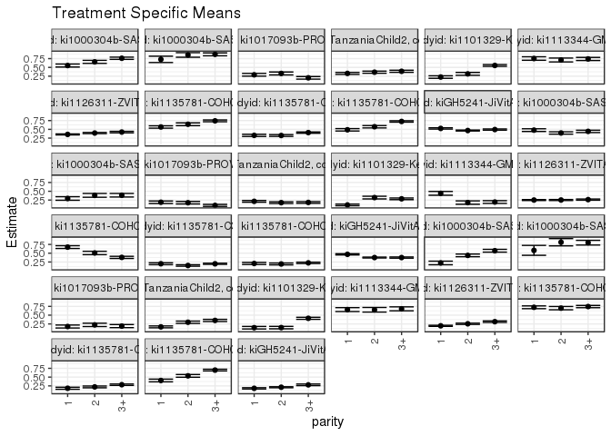

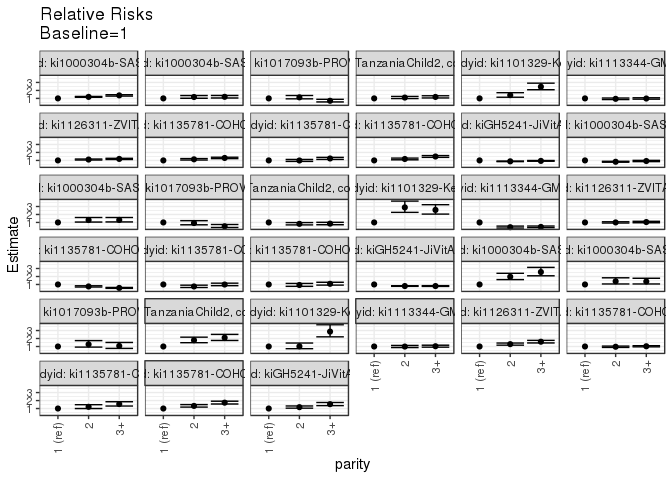

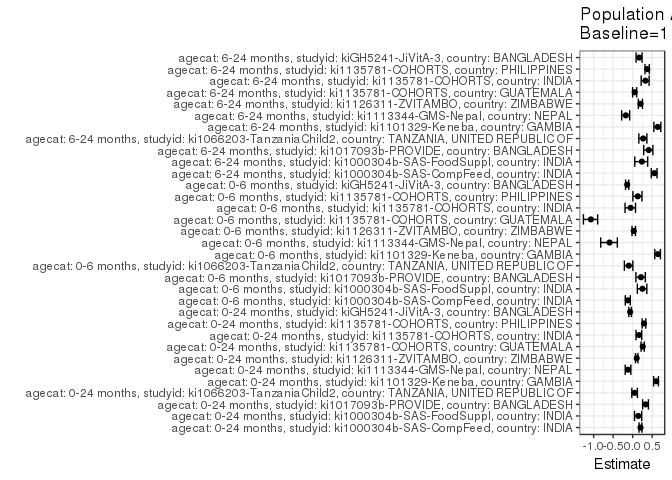

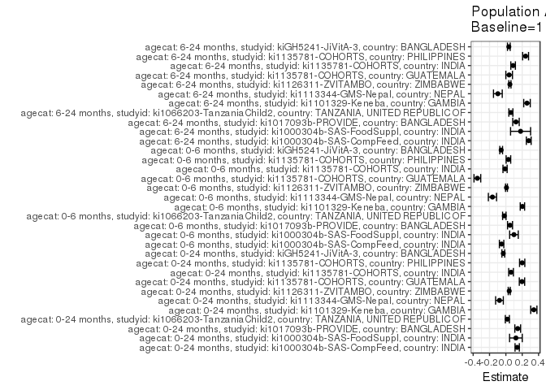

## Results Table

### Parameter: TSM

| agecat | studyid | country | intervention_level | baseline_level | estimate | ci_lower | ci_upper |
| --- | --- | --- | --- | --- | --- | --- | --- |
| 0-24 months | ki1000304b-SAS-CompFeed | INDIA | 1 | NA | 0.5528314 | 0.5099778 | 0.5956849 |
| 0-24 months | ki1000304b-SAS-CompFeed | INDIA | 2 | NA | 0.6578289 | 0.6146487 | 0.7010091 |
| 0-24 months | ki1000304b-SAS-CompFeed | INDIA | 3+ | NA | 0.7604356 | 0.7286141 | 0.7922571 |
| 0-24 months | ki1000304b-SAS-FoodSuppl | INDIA | 1 | NA | 0.7285387 | 0.6381367 | 0.8189407 |
| 0-24 months | ki1000304b-SAS-FoodSuppl | INDIA | 2 | NA | 0.8550799 | 0.7898484 | 0.9203114 |
| 0-24 months | ki1000304b-SAS-FoodSuppl | INDIA | 3+ | NA | 0.8718586 | 0.8297807 | 0.9139364 |
| 0-24 months | ki1017093b-PROVIDE | BANGLADESH | 1 | NA | 0.2893066 | 0.2506926 | 0.3279206 |
| 0-24 months | ki1017093b-PROVIDE | BANGLADESH | 2 | NA | 0.3275923 | 0.2861001 | 0.3690845 |
| 0-24 months | ki1017093b-PROVIDE | BANGLADESH | 3+ | NA | 0.2030072 | 0.1662911 | 0.2397234 |
| 0-24 months | ki1066203-TanzaniaChild2 | TANZANIA, UNITED REPUBLIC OF | 1 | NA | 0.3289038 | 0.3002830 | 0.3575246 |
| 0-24 months | ki1066203-TanzaniaChild2 | TANZANIA, UNITED REPUBLIC OF | 2 | NA | 0.3634025 | 0.3331603 | 0.3936446 |
| 0-24 months | ki1066203-TanzaniaChild2 | TANZANIA, UNITED REPUBLIC OF | 3+ | NA | 0.3890447 | 0.3593148 | 0.4187745 |
| 0-24 months | ki1101329-Keneba | GAMBIA | 1 | NA | 0.2252273 | 0.1894380 | 0.2610166 |
| 0-24 months | ki1101329-Keneba | GAMBIA | 2 | NA | 0.3158747 | 0.2748509 | 0.3568986 |
| 0-24 months | ki1101329-Keneba | GAMBIA | 3+ | NA | 0.5548843 | 0.5295543 | 0.5802143 |
| 0-24 months | ki1113344-GMS-Nepal | NEPAL | 1 | NA | 0.7526122 | 0.7031142 | 0.8021102 |
| 0-24 months | ki1113344-GMS-Nepal | NEPAL | 2 | NA | 0.7112489 | 0.6558887 | 0.7666091 |
| 0-24 months | ki1113344-GMS-Nepal | NEPAL | 3+ | NA | 0.7407334 | 0.6967871 | 0.7846798 |
| 0-24 months | ki1126311-ZVITAMBO | ZIMBABWE | 1 | NA | 0.3554162 | 0.3412493 | 0.3695832 |
| 0-24 months | ki1126311-ZVITAMBO | ZIMBABWE | 2 | NA | 0.3945201 | 0.3782644 | 0.4107758 |
| 0-24 months | ki1126311-ZVITAMBO | ZIMBABWE | 3+ | NA | 0.4221495 | 0.4012349 | 0.4430640 |
| 0-24 months | ki1135781-COHORTS | GUATEMALA | 1 | NA | 0.5667960 | 0.5328514 | 0.6007406 |
| 0-24 months | ki1135781-COHORTS | GUATEMALA | 2 | NA | 0.6446920 | 0.6050480 | 0.6843360 |
| 0-24 months | ki1135781-COHORTS | GUATEMALA | 3+ | NA | 0.7414085 | 0.7156864 | 0.7671307 |
| 0-24 months | ki1135781-COHORTS | INDIA | 1 | NA | 0.3278115 | 0.2973726 | 0.3582504 |
| 0-24 months | ki1135781-COHORTS | INDIA | 2 | NA | 0.3243973 | 0.2982262 | 0.3505684 |
| 0-24 months | ki1135781-COHORTS | INDIA | 3+ | NA | 0.4075054 | 0.3885904 | 0.4264205 |
| 0-24 months | ki1135781-COHORTS | PHILIPPINES | 1 | NA | 0.4867805 | 0.4522663 | 0.5212947 |
| 0-24 months | ki1135781-COHORTS | PHILIPPINES | 2 | NA | 0.5742652 | 0.5407358 | 0.6077945 |
| 0-24 months | ki1135781-COHORTS | PHILIPPINES | 3+ | NA | 0.7246699 | 0.7047675 | 0.7445722 |

[output cut: 69 more lines]

### Parameter: E(Y)

| agecat | studyid | country | intervention_level | baseline_level | estimate | ci_lower | ci_upper |
| --- | --- | --- | --- | --- | --- | --- | --- |
| 0-24 months | ki1000304b-SAS-CompFeed | INDIA | NA | NA | 0.6914547 | 0.6510509 | 0.7318584 |
| 0-24 months | ki1000304b-SAS-FoodSuppl | INDIA | NA | NA | 0.8513854 | 0.8163510 | 0.8864198 |
| 0-24 months | ki1017093b-PROVIDE | BANGLADESH | NA | NA | 0.4342857 | 0.3975409 | 0.4710305 |
| 0-24 months | ki1066203-TanzaniaChild2 | TANZANIA, UNITED REPUBLIC OF | NA | NA | 0.3470513 | 0.3278294 | 0.3662733 |
| 0-24 months | ki1101329-Keneba | GAMBIA | NA | NA | 0.5673367 | 0.5455633 | 0.5891101 |
| 0-24 months | ki1113344-GMS-Nepal | NEPAL | NA | NA | 0.6744186 | 0.6369554 | 0.7118819 |
| 0-24 months | ki1126311-ZVITAMBO | ZIMBABWE | NA | NA | 0.3966032 | 0.3885203 | 0.4046860 |
| 0-24 months | ki1135781-COHORTS | GUATEMALA | NA | NA | 0.7639706 | 0.7413939 | 0.7865473 |
| 0-24 months | ki1135781-COHORTS | INDIA | NA | NA | 0.3911447 | 0.3770865 | 0.4052029 |
| 0-24 months | ki1135781-COHORTS | PHILIPPINES | NA | NA | 0.6863963 | 0.6699497 | 0.7028430 |
| 0-24 months | kiGH5241-JiVitA-3 | BANGLADESH | NA | NA | 0.4940677 | 0.4862211 | 0.5019142 |
| 0-6 months | ki1000304b-SAS-CompFeed | INDIA | NA | NA | 0.4254902 | 0.3977202 | 0.4532601 |
| 0-6 months | ki1000304b-SAS-FoodSuppl | INDIA | NA | NA | 0.3939394 | 0.3457532 | 0.4421255 |
| 0-6 months | ki1017093b-PROVIDE | BANGLADESH | NA | NA | 0.2385714 | 0.2069753 | 0.2701675 |
| 0-6 months | ki1066203-TanzaniaChild2 | TANZANIA, UNITED REPUBLIC OF | NA | NA | 0.1947391 | 0.1787488 | 0.2107293 |
| 0-6 months | ki1101329-Keneba | GAMBIA | NA | NA | 0.3135456 | 0.2924164 | 0.3346748 |
| 0-6 months | ki1113344-GMS-Nepal | NEPAL | NA | NA | 0.2774086 | 0.2416141 | 0.3132032 |
| 0-6 months | ki1126311-ZVITAMBO | ZIMBABWE | NA | NA | 0.2580071 | 0.2507721 | 0.2652422 |
| 0-6 months | ki1135781-COHORTS | GUATEMALA | NA | NA | 0.3253896 | 0.2975756 | 0.3532035 |
| 0-6 months | ki1135781-COHORTS | INDIA | NA | NA | 0.1902526 | 0.1787489 | 0.2017563 |
| 0-6 months | ki1135781-COHORTS | PHILIPPINES | NA | NA | 0.2390451 | 0.2239262 | 0.2541640 |
| 0-6 months | kiGH5241-JiVitA-3 | BANGLADESH | NA | NA | 0.4108676 | 0.4034192 | 0.4183159 |
| 6-24 months | ki1000304b-SAS-CompFeed | INDIA | NA | NA | 0.5030750 | 0.4588491 | 0.5473009 |
| 6-24 months | ki1000304b-SAS-FoodSuppl | INDIA | NA | NA | 0.7615063 | 0.7073642 | 0.8156483 |
| 6-24 months | ki1017093b-PROVIDE | BANGLADESH | NA | NA | 0.2997812 | 0.2577294 | 0.3418330 |
| 6-24 months | ki1066203-TanzaniaChild2 | TANZANIA, UNITED REPUBLIC OF | NA | NA | 0.2276474 | 0.2069456 | 0.2483493 |
| 6-24 months | ki1101329-Keneba | GAMBIA | NA | NA | 0.4014652 | 0.3754511 | 0.4274793 |
| 6-24 months | ki1113344-GMS-Nepal | NEPAL | NA | NA | 0.5610329 | 0.5138522 | 0.6082135 |
| 6-24 months | ki1126311-ZVITAMBO | ZIMBABWE | NA | NA | 0.2458522 | 0.2363900 | 0.2553144 |
| 6-24 months | ki1135781-COHORTS | GUATEMALA | NA | NA | 0.7642458 | 0.7364214 | 0.7920702 |
| 6-24 months | ki1135781-COHORTS | INDIA | NA | NA | 0.2705750 | 0.2559548 | 0.2851951 |
| 6-24 months | ki1135781-COHORTS | PHILIPPINES | NA | NA | 0.6449788 | 0.6246093 | 0.6653483 |
| 6-24 months | kiGH5241-JiVitA-3 | BANGLADESH | NA | NA | 0.2169852 | 0.2076274 | 0.2263430 |

### Parameter: RR

| agecat | studyid | country | intervention_level | baseline_level | estimate | ci_lower | ci_upper |
| --- | --- | --- | --- | --- | --- | --- | --- |
| 0-24 months | ki1000304b-SAS-CompFeed | INDIA | 1 | 1 | 1.0000000 | 1.0000000 | 1.0000000 |
| 0-24 months | ki1000304b-SAS-CompFeed | INDIA | 2 | 1 | 1.1899269 | 1.1411918 | 1.2407431 |
| 0-24 months | ki1000304b-SAS-CompFeed | INDIA | 3+ | 1 | 1.3755290 | 1.2908812 | 1.4657275 |
| 0-24 months | ki1000304b-SAS-FoodSuppl | INDIA | 1 | 1 | 1.0000000 | 1.0000000 | 1.0000000 |
| 0-24 months | ki1000304b-SAS-FoodSuppl | INDIA | 2 | 1 | 1.1736918 | 1.0148876 | 1.3573449 |
| 0-24 months | ki1000304b-SAS-FoodSuppl | INDIA | 3+ | 1 | 1.1967224 | 1.0483744 | 1.3660621 |
| 0-24 months | ki1017093b-PROVIDE | BANGLADESH | 1 | 1 | 1.0000000 | 1.0000000 | 1.0000000 |
| 0-24 months | ki1017093b-PROVIDE | BANGLADESH | 2 | 1 | 1.1323361 | 0.9423853 | 1.3605741 |
| 0-24 months | ki1017093b-PROVIDE | BANGLADESH | 3+ | 1 | 0.7017027 | 0.5568819 | 0.8841852 |
| 0-24 months | ki1066203-TanzaniaChild2 | TANZANIA, UNITED REPUBLIC OF | 1 | 1 | 1.0000000 | 1.0000000 | 1.0000000 |
| 0-24 months | ki1066203-TanzaniaChild2 | TANZANIA, UNITED REPUBLIC OF | 2 | 1 | 1.1048897 | 0.9804074 | 1.2451775 |
| 0-24 months | ki1066203-TanzaniaChild2 | TANZANIA, UNITED REPUBLIC OF | 3+ | 1 | 1.1828523 | 1.0542790 | 1.3271057 |
| 0-24 months | ki1101329-Keneba | GAMBIA | 1 | 1 | 1.0000000 | 1.0000000 | 1.0000000 |
| 0-24 months | ki1101329-Keneba | GAMBIA | 2 | 1 | 1.4024708 | 1.1481875 | 1.7130690 |
| 0-24 months | ki1101329-Keneba | GAMBIA | 3+ | 1 | 2.4636636 | 2.0873628 | 2.9078023 |
| 0-24 months | ki1113344-GMS-Nepal | NEPAL | 1 | 1 | 1.0000000 | 1.0000000 | 1.0000000 |
| 0-24 months | ki1113344-GMS-Nepal | NEPAL | 2 | 1 | 0.9450404 | 0.8535849 | 1.0462947 |
| 0-24 months | ki1113344-GMS-Nepal | NEPAL | 3+ | 1 | 0.9842166 | 0.9005217 | 1.0756902 |
| 0-24 months | ki1126311-ZVITAMBO | ZIMBABWE | 1 | 1 | 1.0000000 | 1.0000000 | 1.0000000 |
| 0-24 months | ki1126311-ZVITAMBO | ZIMBABWE | 2 | 1 | 1.1100227 | 1.0485556 | 1.1750930 |
| 0-24 months | ki1126311-ZVITAMBO | ZIMBABWE | 3+ | 1 | 1.1877607 | 1.1148321 | 1.2654602 |
| 0-24 months | ki1135781-COHORTS | GUATEMALA | 1 | 1 | 1.0000000 | 1.0000000 | 1.0000000 |
| 0-24 months | ki1135781-COHORTS | GUATEMALA | 2 | 1 | 1.1374322 | 1.0487226 | 1.2336457 |
| 0-24 months | ki1135781-COHORTS | GUATEMALA | 3+ | 1 | 1.3080695 | 1.2233916 | 1.3986084 |
| 0-24 months | ki1135781-COHORTS | INDIA | 1 | 1 | 1.0000000 | 1.0000000 | 1.0000000 |
| 0-24 months | ki1135781-COHORTS | INDIA | 2 | 1 | 0.9895848 | 0.8757136 | 1.1182631 |
| 0-24 months | ki1135781-COHORTS | INDIA | 3+ | 1 | 1.2431091 | 1.1212149 | 1.3782551 |
| 0-24 months | ki1135781-COHORTS | PHILIPPINES | 1 | 1 | 1.0000000 | 1.0000000 | 1.0000000 |
| 0-24 months | ki1135781-COHORTS | PHILIPPINES | 2 | 1 | 1.1797210 | 1.0779527 | 1.2910973 |
| 0-24 months | ki1135781-COHORTS | PHILIPPINES | 3+ | 1 | 1.4886996 | 1.3801976 | 1.6057313 |

[output cut: 69 more lines]

### Parameter: PAR

| agecat | studyid | country | intervention_level | baseline_level | estimate | ci_lower | ci_upper |
| --- | --- | --- | --- | --- | --- | --- | --- |
| 0-24 months | ki1000304b-SAS-CompFeed | INDIA | 1 | NA | 0.1386233 | 0.1125141 | 0.1647325 |
| 0-24 months | ki1000304b-SAS-FoodSuppl | INDIA | 1 | NA | 0.1228467 | 0.0453153 | 0.2003781 |
| 0-24 months | ki1017093b-PROVIDE | BANGLADESH | 1 | NA | 0.1449791 | 0.1097320 | 0.1802262 |
| 0-24 months | ki1066203-TanzaniaChild2 | TANZANIA, UNITED REPUBLIC OF | 1 | NA | 0.0181475 | -0.0066857 | 0.0429807 |
| 0-24 months | ki1101329-Keneba | GAMBIA | 1 | NA | 0.3421094 | 0.3043161 | 0.3799027 |
| 0-24 months | ki1113344-GMS-Nepal | NEPAL | 1 | NA | -0.0781936 | -0.1252446 | -0.0311425 |
| 0-24 months | ki1126311-ZVITAMBO | ZIMBABWE | 1 | NA | 0.0411869 | 0.0287801 | 0.0535938 |
| 0-24 months | ki1135781-COHORTS | GUATEMALA | 1 | NA | 0.1971746 | 0.1643961 | 0.2299531 |
| 0-24 months | ki1135781-COHORTS | INDIA | 1 | NA | 0.0633332 | 0.0344653 | 0.0922012 |
| 0-24 months | ki1135781-COHORTS | PHILIPPINES | 1 | NA | 0.1996159 | 0.1674665 | 0.2317652 |
| 0-24 months | kiGH5241-JiVitA-3 | BANGLADESH | 1 | NA | -0.0316759 | -0.0483209 | -0.0150309 |
| 0-6 months | ki1000304b-SAS-CompFeed | INDIA | 1 | NA | -0.0523444 | -0.0794425 | -0.0252462 |
| 0-6 months | ki1000304b-SAS-FoodSuppl | INDIA | 1 | NA | 0.0989406 | 0.0462945 | 0.1515866 |
| 0-6 months | ki1017093b-PROVIDE | BANGLADESH | 1 | NA | 0.0507768 | 0.0203800 | 0.0811737 |
| 0-6 months | ki1066203-TanzaniaChild2 | TANZANIA, UNITED REPUBLIC OF | 1 | NA | -0.0191414 | -0.0400416 | 0.0017589 |
| 0-6 months | ki1101329-Keneba | GAMBIA | 1 | NA | 0.2024941 | 0.1758319 | 0.2291563 |
| 0-6 months | ki1113344-GMS-Nepal | NEPAL | 1 | NA | -0.1641720 | -0.2141917 | -0.1141522 |
| 0-6 months | ki1126311-ZVITAMBO | ZIMBABWE | 1 | NA | 0.0073245 | -0.0040730 | 0.0187219 |
| 0-6 months | ki1135781-COHORTS | GUATEMALA | 1 | NA | -0.3487373 | -0.3897045 | -0.3077701 |
| 0-6 months | ki1135781-COHORTS | INDIA | 1 | NA | -0.0099939 | -0.0354172 | 0.0154294 |
| 0-6 months | ki1135781-COHORTS | PHILIPPINES | 1 | NA | 0.0311233 | 0.0031054 | 0.0591412 |
| 0-6 months | kiGH5241-JiVitA-3 | BANGLADESH | 1 | NA | -0.0575388 | -0.0744447 | -0.0406330 |
| 6-24 months | ki1000304b-SAS-CompFeed | INDIA | 1 | NA | 0.2799869 | 0.2505760 | 0.3093978 |
| 6-24 months | ki1000304b-SAS-FoodSuppl | INDIA | 1 | NA | 0.1800506 | 0.0575055 | 0.3025957 |
| 6-24 months | ki1017093b-PROVIDE | BANGLADESH | 1 | NA | 0.1236087 | 0.0840396 | 0.1631778 |
| 6-24 months | ki1066203-TanzaniaChild2 | TANZANIA, UNITED REPUBLIC OF | 1 | NA | 0.0611231 | 0.0365117 | 0.0857345 |
| 6-24 months | ki1101329-Keneba | GAMBIA | 1 | NA | 0.2583749 | 0.2184289 | 0.2983209 |
| 6-24 months | ki1113344-GMS-Nepal | NEPAL | 1 | NA | -0.0979338 | -0.1514171 | -0.0444505 |
| 6-24 months | ki1126311-ZVITAMBO | ZIMBABWE | 1 | NA | 0.0492493 | 0.0360363 | 0.0624624 |
| 6-24 months | ki1135781-COHORTS | GUATEMALA | 1 | NA | 0.0400914 | -0.0002472 | 0.0804300 |
| 6-24 months | ki1135781-COHORTS | INDIA | 1 | NA | 0.0885655 | 0.0605632 | 0.1165677 |
| 6-24 months | ki1135781-COHORTS | PHILIPPINES | 1 | NA | 0.2412895 | 0.2050192 | 0.2775598 |
| 6-24 months | kiGH5241-JiVitA-3 | BANGLADESH | 1 | NA | 0.0363766 | 0.0196822 | 0.0530710 |

### Parameter: PAF

| agecat | studyid | country | intervention_level | baseline_level | estimate | ci_lower | ci_upper |
| --- | --- | --- | --- | --- | --- | --- | --- |
| 0-24 months | ki1000304b-SAS-CompFeed | INDIA | 1 | NA | 0.2004807 | 0.1627002 | 0.2365564 |
| 0-24 months | ki1000304b-SAS-FoodSuppl | INDIA | 1 | NA | 0.1442904 | 0.0468604 | 0.2317610 |
| 0-24 months | ki1017093b-PROVIDE | BANGLADESH | 1 | NA | 0.3338335 | 0.2558750 | 0.4036246 |
| 0-24 months | ki1066203-TanzaniaChild2 | TANZANIA, UNITED REPUBLIC OF | 1 | NA | 0.0522906 | -0.0215503 | 0.1207940 |
| 0-24 months | ki1101329-Keneba | GAMBIA | 1 | NA | 0.6030094 | 0.5362389 | 0.6601666 |
| 0-24 months | ki1113344-GMS-Nepal | NEPAL | 1 | NA | -0.1159422 | -0.1904801 | -0.0460713 |
| 0-24 months | ki1126311-ZVITAMBO | ZIMBABWE | 1 | NA | 0.1038492 | 0.0721429 | 0.1344722 |
| 0-24 months | ki1135781-COHORTS | GUATEMALA | 1 | NA | 0.2580919 | 0.2155903 | 0.2982905 |
| 0-24 months | ki1135781-COHORTS | INDIA | 1 | NA | 0.1619176 | 0.0853359 | 0.2320874 |
| 0-24 months | ki1135781-COHORTS | PHILIPPINES | 1 | NA | 0.2908172 | 0.2426392 | 0.3359305 |
| 0-24 months | kiGH5241-JiVitA-3 | BANGLADESH | 1 | NA | -0.0641125 | -0.0983804 | -0.0309137 |
| 0-6 months | ki1000304b-SAS-CompFeed | INDIA | 1 | NA | -0.1230213 | -0.1893615 | -0.0603814 |
| 0-6 months | ki1000304b-SAS-FoodSuppl | INDIA | 1 | NA | 0.2511568 | 0.1196752 | 0.3630009 |
| 0-6 months | ki1017093b-PROVIDE | BANGLADESH | 1 | NA | 0.2128370 | 0.0831763 | 0.3241605 |
| 0-6 months | ki1066203-TanzaniaChild2 | TANZANIA, UNITED REPUBLIC OF | 1 | NA | -0.0982924 | -0.2123869 | 0.0050650 |
| 0-6 months | ki1101329-Keneba | GAMBIA | 1 | NA | 0.6458204 | 0.5667199 | 0.7104801 |
| 0-6 months | ki1113344-GMS-Nepal | NEPAL | 1 | NA | -0.5918056 | -0.8189976 | -0.3929897 |
| 0-6 months | ki1126311-ZVITAMBO | ZIMBABWE | 1 | NA | 0.0283886 | -0.0167487 | 0.0715220 |
| 0-6 months | ki1135781-COHORTS | GUATEMALA | 1 | NA | -1.0717532 | -1.2624153 | -0.8971589 |
| 0-6 months | ki1135781-COHORTS | INDIA | 1 | NA | -0.0525298 | -0.1953485 | 0.0732251 |
| 0-6 months | ki1135781-COHORTS | PHILIPPINES | 1 | NA | 0.1301985 | 0.0059570 | 0.2389115 |
| 0-6 months | kiGH5241-JiVitA-3 | BANGLADESH | 1 | NA | -0.1400423 | -0.1820578 | -0.0995202 |
| 6-24 months | ki1000304b-SAS-CompFeed | INDIA | 1 | NA | 0.5565510 | 0.4764601 | 0.6243896 |
| 6-24 months | ki1000304b-SAS-FoodSuppl | INDIA | 1 | NA | 0.2364401 | 0.0532523 | 0.3841825 |
| 6-24 months | ki1017093b-PROVIDE | BANGLADESH | 1 | NA | 0.4123297 | 0.2830502 | 0.5182978 |
| 6-24 months | ki1066203-TanzaniaChild2 | TANZANIA, UNITED REPUBLIC OF | 1 | NA | 0.2684989 | 0.1583214 | 0.3642540 |
| 6-24 months | ki1101329-Keneba | GAMBIA | 1 | NA | 0.6435798 | 0.5437711 | 0.7215535 |
| 6-24 months | ki1113344-GMS-Nepal | NEPAL | 1 | NA | -0.1745599 | -0.2812179 | -0.0767809 |
| 6-24 months | ki1126311-ZVITAMBO | ZIMBABWE | 1 | NA | 0.2003209 | 0.1455784 | 0.2515561 |
| 6-24 months | ki1135781-COHORTS | GUATEMALA | 1 | NA | 0.0524588 | -0.0011094 | 0.1031606 |
| 6-24 months | ki1135781-COHORTS | INDIA | 1 | NA | 0.3273231 | 0.2178669 | 0.4214614 |
| 6-24 months | ki1135781-COHORTS | PHILIPPINES | 1 | NA | 0.3741045 | 0.3160112 | 0.4272638 |
| 6-24 months | kiGH5241-JiVitA-3 | BANGLADESH | 1 | NA | 0.1676455 | 0.0880592 | 0.2402863 |